# ISLR Unit 3 Exercises

Brent Lockee

Thursday, March 24, 2016

Conceptual

1. Describe the null hypotheses to which the p-values given in Table 3.4 correspond. Explain what conclusions you can draw based on these p-values. Your explanation should be phrased in terms of sales, TV, radio, and newspaper, rather than in terms of the coefficients of the linear model.

The null hypothesis on the TV line is that holding radio and newspaper fixed, TV has no effect on sales. On the radio line, the null hypothesis is that while holding TV and newpaper fixed, radio has no impact on sales. On the newspaper line, the null hypothesis is that while holding radio and TV fixed, newspaper has no effect on sales. The null hypothesis for the intercept line is that the intercept value is zero. From the given p values, we are able to reject the null hypothesis regarding the intercept, TV, and radio. We are not able to reject the null hypothesis for newspaper.

2. Carefully explain the differences between the KNN classifier and KNN regression methods.

The KNN regression method seeks to estimate the function for a given point by averaging the response of the specified number of neighbors. This is required because KNN regression deals with quantitative values rather than qualitative. KNN Classification assigns a point, x, to a class based on its most likely class given the classes of its neighbors.

3. Suppose we have a data set with five predictors, X1 =GPA, X2 = IQ, X3 = Gender (1 for Female and 0 forMale), X4 = Interaction between GPA and IQ, and X5 = Interaction between GPA and Gender. The response is starting salary after graduation (in thousands of dollars). Suppose we use least squares to fit the model, and get ˆß0 = 50, ˆß1 = 20, ˆß2 = 0.07, ˆß3 = 35, ˆß4 = 0.01, ˆß5 = -10.
1. Which answer is correct, and why?
1. For a fixed value of IQ and GPA, males earn more on average than females.
2. For a fixed value of IQ and GPA, females earn more on average than males.
3. For a fixed value of IQ and GPA, males earn more on average than females provided that the GPA is high enough.

Correct iii

4. For a fixed value of IQ and GPA, females earn more on average than males provided that the GPA is high enough.
2. Predict the salary of a female with IQ of 110 and a GPA of 4.0.

```r
50 + 20*4 + .07*110 + 35 + .01*4*110 + -10*4
```

```
## [1] 137.1
```

3. True or false: Since the coefficient for the GPA/IQ interaction term is very small, there is very little evidence of an interaction effect. Justify your answer.

False. A small coefficient could still be significant if the p value is small enough. The small coefficient could be a result of the scale of the variables: IQ has an average of 100 in the population while GPA has a maximum of 4. They have very different scales.

4. I collect a set of data (n = 100 observations) containing a single predictor and a quantitative response. I then fit a linear regression model to the data, as well as a separate cubic regression, i.e. Y = ß0 + ß1X + ß2X2 + ß3X3 + .
1. Suppose that the true relationship between X and Y is linear, i.e. Y = ß0 + ß1X + . Consider the training residual sum of squares (RSS) for the linear regression, and also the training RSS for the cubic regression. Would we expect one to be lower than the other, would we expect them to be the same, or is there not enough information to tell? Justify your answer.

The RSS for the cubic regression will be lower because adding features always lowers the training RSS.

2. Answer (a) using test rather than training RSS.

The Test RSS will most likely be higher for the cubic regression because the relationship is truly linear and adding squared and cubic terms added to the variance of the model and allowed some measure of overfitting to the training data.

3. Suppose that the true relationship between X and Y is not linear, but we don’t know how far it is from linear. Consider the training RSS for the linear regression, and also the training RSS for the cubic regression. Would we expect one to be lower than the other, would we expect them to be the same, or is there not enough information to tell? Justify your answer.

The training RSS for the cubic regression would be lower than for the linear regression because adding features lowers the training RSS.

4. Answer (c) using test rather than training RSS.

Not enough information. If the bias of the linear model is less than the variance introduced by the cubic regression, it will have a lower RSS. The opposite, more bias in the linear model than variance added by the cubic regression, would result in a lower RSS for the cubic regression. Without more information, we can’t know which is the case.

Applied

8. This question involves the use of simple linear regression on the Auto data set.

```r
auto <- read.csv("Auto.csv", na.strings = "?")
```

1. Use the lm() function to perform a simple linear regression with mpg as the response and horsepower as the predictor. Use the summary() function to print the results. Comment on the output. For example:

```r
auto.lm <- lm(mpg~horsepower, data=auto)
summary(auto.lm)
```

```
##
## Call:
## lm(formula = mpg ~ horsepower, data = auto)
##
## Residuals:
##      Min       1Q   Median       3Q      Max
## -13.5710  -3.2592  -0.3435   2.7630  16.9240
##
## Coefficients:
##              Estimate Std. Error t value Pr(>|t|)
## (Intercept) 39.935861   0.717499   55.66   <2e-16 ***
## horsepower  -0.157845   0.006446  -24.49   <2e-16 ***
## ---
## Signif. codes:  0 '***' 0.001 '**' 0.01 '*' 0.05 '.' 0.1 ' ' 1
##
## Residual standard error: 4.906 on 390 degrees of freedom
##   (5 observations deleted due to missingness)
## Multiple R-squared:  0.6059, Adjusted R-squared:  0.6049
## F-statistic: 599.7 on 1 and 390 DF,  p-value: < 2.2e-16
```

1. Is there a relationship between the predictor and the response?

Yes, there is clearly a relationship between horsepower and mpg based on the near-zero p value.

2. How strong is the relationship between the predictor and the response?

The significance of the relationship is very strong as indicated by the very low p value. The estimate of the coefficient is -0.158. Horsepower values in this dataset are 5x or more mpg for most entry, so a small coefficient value is expected and does nothing to weaken the case that this is in fact a significant relationship.

3. Is the relationship between the predictor and the response positive or negative?

negative

4. What is the predicted mpg associated with a horsepower of 98? What are the associated 95% confidence and prediction intervals?

```r
prediction.auto <- predict(auto.lm, newdata = data.frame(horsepower = c(98)), interval="confidence")
prediction.auto
```

```
##        fit      lwr      upr
## 1 24.46708 23.97308 24.96108
```

```r
prediction.auto <- predict(auto.lm, newdata = data.frame(horsepower = c(98)), interval="prediction")
prediction.auto
```

```
##        fit     lwr      upr
## 1 24.46708 14.8094 34.12476
```

2. Plot the response and the predictor. Use the abline() function to display the least squares regression line.

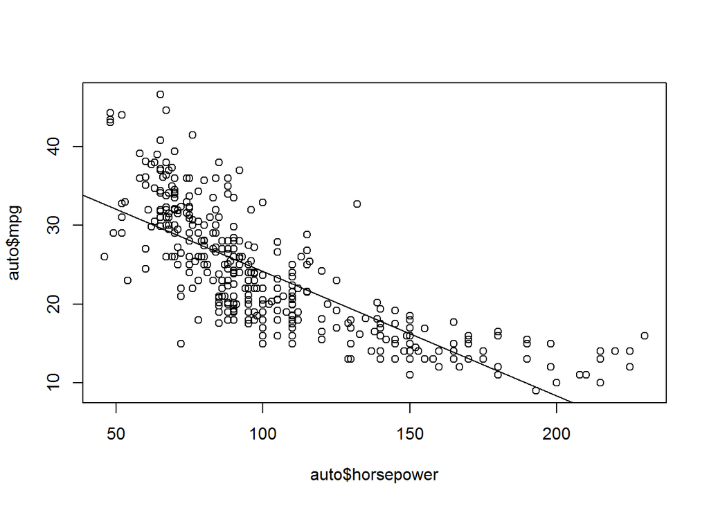

```r
par(mfrow = c(1,1))
plot(auto$horsepower, auto$mpg)
abline(auto.lm)
```

3. Use the plot() function to produce diagnostic plots of the least squares regression fit. Comment on any problems you see with the fit.

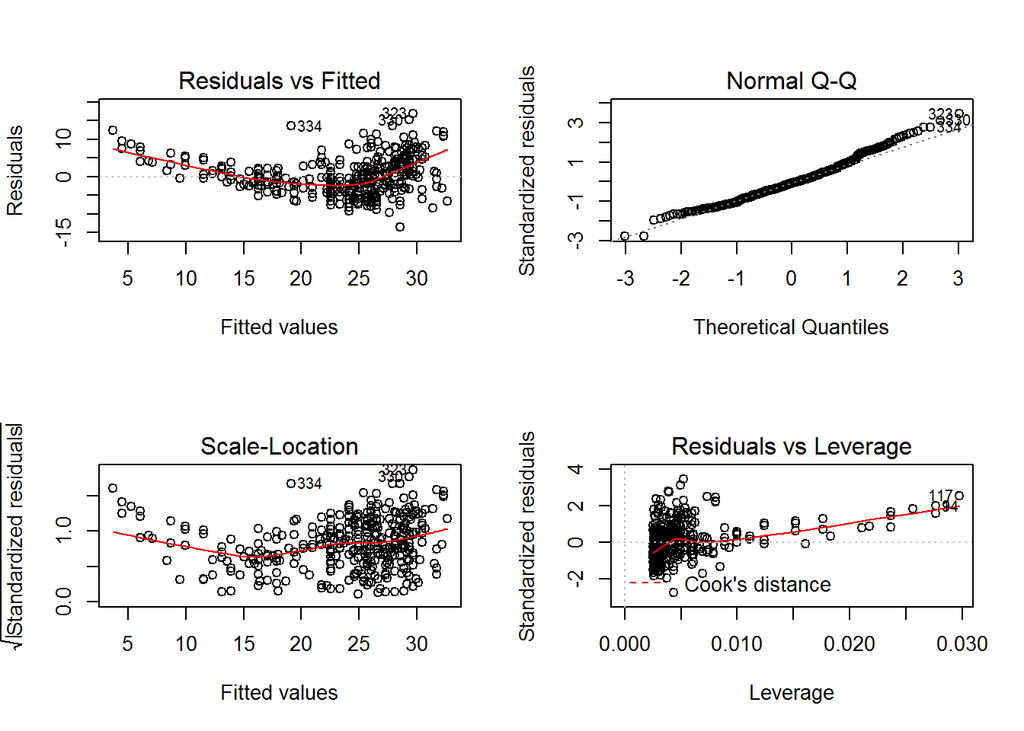

```r
par(mfrow = c(2,2))
plot(auto.lm)
```

The Residuals vs Fitted plot shows evidence of a nonlinear relationship. Residuals spike sharply upward with a fitted value of 25 or more. There are also a handful of high leverage data points as seen in the Residuals vs Leverage plot.

9. This question involves the use of multiple linear regression on the Auto data set.
1. Produce a scatterplot matrix which includes all of the variables in the data set.

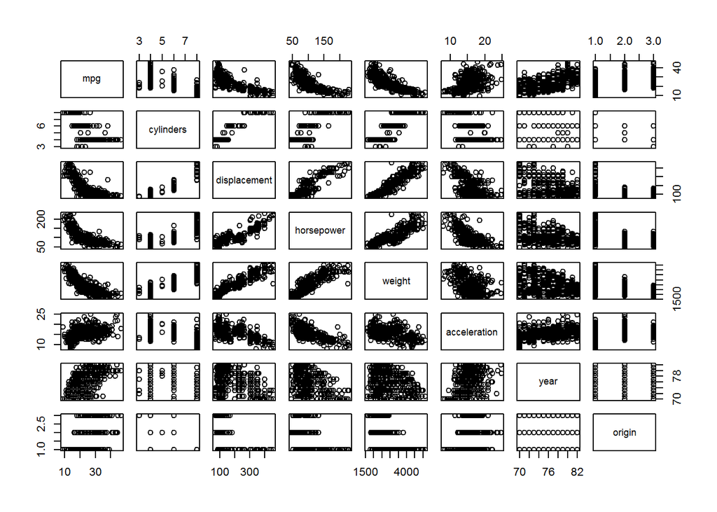

```r
pairs(auto[,1:8])
```

2. Compute the matrix of correlations between the variables using the function cor(). You will need to exclude the name variable, cor() which is qualitative.

```r
auto <- auto[complete.cases(auto),]
cor(auto[,1:8])
```

```
##                     mpg  cylinders displacement horsepower     weight
## mpg           1.0000000 -0.7776175   -0.8051269 -0.7784268 -0.8322442
## cylinders    -0.7776175  1.0000000    0.9508233  0.8429834  0.8975273
## displacement -0.8051269  0.9508233    1.0000000  0.8972570  0.9329944
## horsepower   -0.7784268  0.8429834    0.8972570  1.0000000  0.8645377
## weight       -0.8322442  0.8975273    0.9329944  0.8645377  1.0000000
## acceleration  0.4233285 -0.5046834   -0.5438005 -0.6891955 -0.4168392
## year          0.5805410 -0.3456474   -0.3698552 -0.4163615 -0.3091199
## origin        0.5652088 -0.5689316   -0.6145351 -0.4551715 -0.5850054
##              acceleration       year     origin
## mpg             0.4233285  0.5805410  0.5652088
## cylinders      -0.5046834 -0.3456474 -0.5689316
## displacement   -0.5438005 -0.3698552 -0.6145351
## horsepower     -0.6891955 -0.4163615 -0.4551715
## weight         -0.4168392 -0.3091199 -0.5850054
## acceleration    1.0000000  0.2903161  0.2127458
## year            0.2903161  1.0000000  0.1815277
## origin          0.2127458  0.1815277  1.0000000
```

3. Use the lm() function to perform a multiple linear regression with mpg as the response and all other variables except name as the predictors. Use the summary() function to print the results. Comment on the output. For instance:

```r
auto.lm <- lm(mpg~.-name, data=auto)
summary(auto.lm)
```

```
##
## Call:
## lm(formula = mpg ~ . - name, data = auto)
##
## Residuals:
##     Min      1Q  Median      3Q     Max
## -9.5903 -2.1565 -0.1169  1.8690 13.0604
##
## Coefficients:
##                Estimate Std. Error t value Pr(>|t|)
## (Intercept)  -17.218435   4.644294  -3.707  0.00024 ***
## cylinders     -0.493376   0.323282  -1.526  0.12780
## displacement   0.019896   0.007515   2.647  0.00844 **
## horsepower    -0.016951   0.013787  -1.230  0.21963
## weight        -0.006474   0.000652  -9.929  < 2e-16 ***
## acceleration   0.080576   0.098845   0.815  0.41548
## year           0.750773   0.050973  14.729  < 2e-16 ***
## origin         1.426141   0.278136   5.127 4.67e-07 ***
## ---
## Signif. codes:  0 '***' 0.001 '**' 0.01 '*' 0.05 '.' 0.1 ' ' 1
##
## Residual standard error: 3.328 on 384 degrees of freedom
## Multiple R-squared:  0.8215, Adjusted R-squared:  0.8182
## F-statistic: 252.4 on 7 and 384 DF,  p-value: < 2.2e-16
```

1. Is there a relationship between the predictors and the response?

Yes, overall, the model has a very low p value and accounts for a large percent of the variability of the response with an Adjusted R squared of 0.82.

2. Which predictors appear to have a statistically significant relationship to the response?

3. What does the coefficient for the year variable suggest?

Newer cars have a higher mpg value.

4. Use the plot() function to produce diagnostic plots of the linear regression fit. Comment on any problems you see with the fit. Do the residual plots suggest any unusually large outliers? Does the leverage plot identify any observations with unusually high leverage?

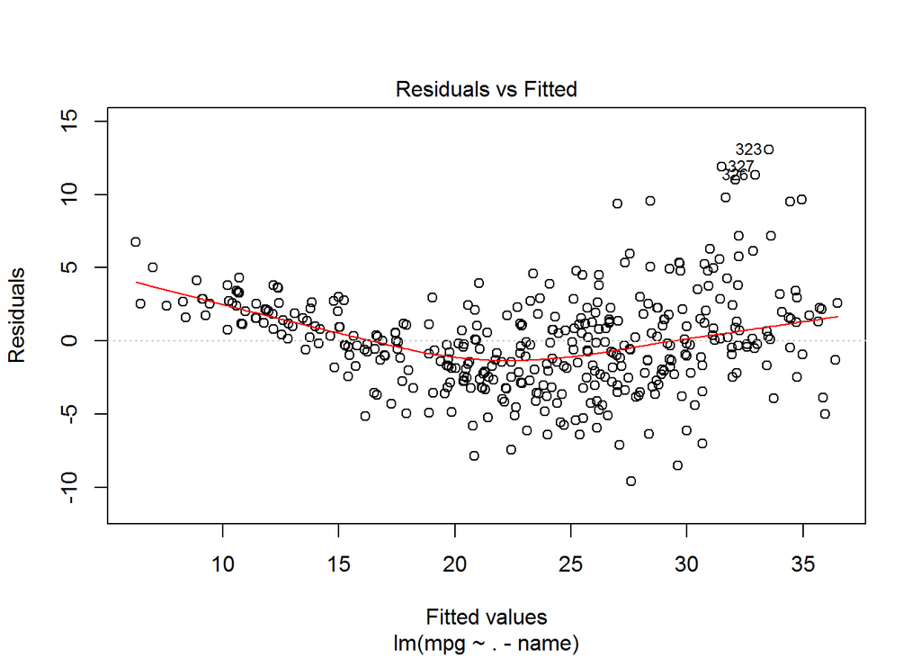

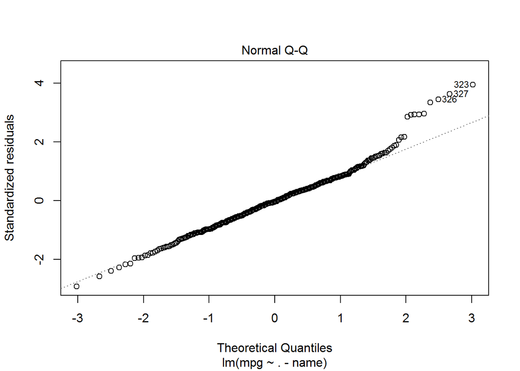

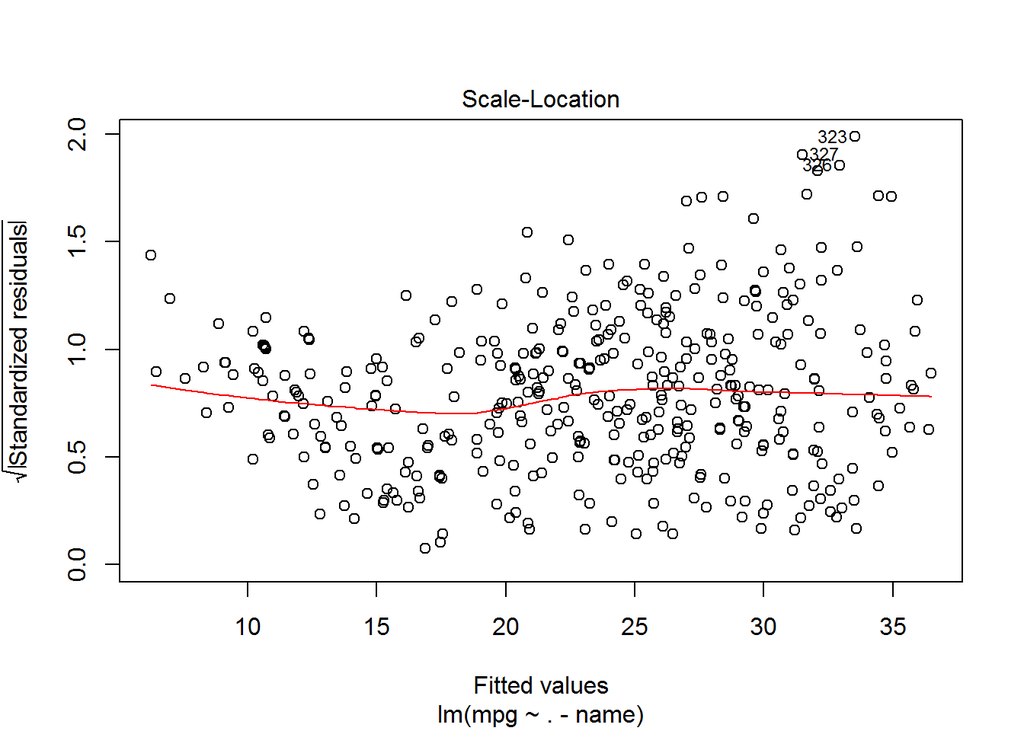

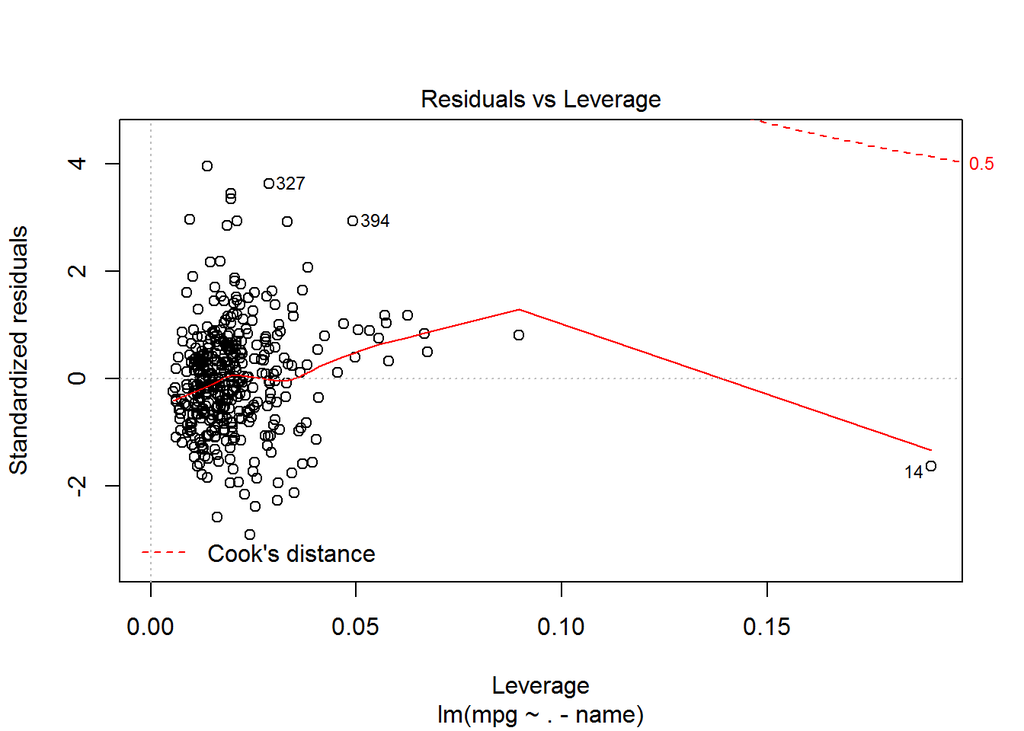

```r
plot(auto.lm)
```

Point 323 has a residual value +4 standard deviations above the average residual value. It isn’t overly concerning because it’s a low leverage point. Point 14 has very high leverage compared to all the other points.

5. Use the * and : symbols to fit linear regression models with interaction effects. Do any interactions appear to be statistically significant?

```r
auto.lm2 <- lm(mpg~origin*year*weight*displacement, data = auto)
summary(auto.lm2)
```

```
##
## Call:
## lm(formula = mpg ~ origin * year * weight * displacement, data = auto)
##
## Residuals:
##      Min       1Q   Median       3Q      Max
## -10.2148  -1.5712  -0.0295   1.3200  14.3708
##
## Coefficients:
##                                   Estimate Std. Error t value Pr(>|t|)
## (Intercept)                     -1.799e+02  1.174e+02  -1.532   0.1262
## origin                           1.984e+01  9.933e+01   0.200   0.8418
## year                             3.017e+00  1.540e+00   1.959   0.0508 .
## weight                           8.198e-02  5.106e-02   1.605   0.1092
## displacement                    -1.019e+00  1.047e+00  -0.973   0.3312
## origin:year                     -2.073e-01  1.297e+00  -0.160   0.8731
## origin:weight                   -3.674e-02  4.435e-02  -0.828   0.4080
## year:weight                     -1.177e-03  6.687e-04  -1.760   0.0793 .
## origin:displacement              1.421e+00  1.002e+00   1.417   0.1572
## year:displacement                1.249e-02  1.371e-02   0.911   0.3629
## weight:displacement              2.297e-04  3.996e-04   0.575   0.5656
## origin:year:weight               4.531e-04  5.779e-04   0.784   0.4335
## origin:year:displacement        -1.874e-02  1.307e-02  -1.434   0.1524
## origin:weight:displacement      -3.598e-04  3.932e-04  -0.915   0.3608
## year:weight:displacement        -2.856e-06  5.197e-06  -0.550   0.5830
## origin:year:weight:displacement  4.824e-06  5.106e-06   0.945   0.3454
## ---
## Signif. codes:  0 '***' 0.001 '**' 0.01 '*' 0.05 '.' 0.1 ' ' 1
##
## Residual standard error: 2.901 on 376 degrees of freedom
## Multiple R-squared:  0.8672, Adjusted R-squared:  0.8619
## F-statistic: 163.6 on 15 and 376 DF,  p-value: < 2.2e-16
```

```r
auto.lm3 <- lm(mpg~origin+year+displacement+weight+origin:year+year:weight+origin:displacement+origin:year:displacement, data = auto)
summary(auto.lm3)
```

```
##
## Call:
## lm(formula = mpg ~ origin + year + displacement + weight + origin:year +
##     year:weight + origin:displacement + origin:year:displacement,
##     data = auto)
##
## Residuals:
##      Min       1Q   Median       3Q      Max
## -10.3588  -1.7870  -0.1707   1.4769  11.7748
##
## Coefficients:
##                            Estimate Std. Error t value Pr(>|t|)
## (Intercept)              -1.242e+02  2.903e+01  -4.278 2.39e-05 ***
## origin                    9.902e+00  9.483e+00   1.044 0.297059
## year                      2.149e+00  3.876e-01   5.546 5.46e-08 ***
## displacement              1.750e-02  8.323e-03   2.103 0.036132 *
## weight                    3.380e-02  1.098e-02   3.078 0.002234 **
## origin:year              -9.340e-02  1.249e-01  -0.748 0.455051
## year:weight              -5.303e-04  1.476e-04  -3.594 0.000368 ***
## origin:displacement      -9.835e-02  8.295e-02  -1.186 0.236483
## origin:year:displacement  1.058e-03  1.086e-03   0.974 0.330697
## ---
## Signif. codes:  0 '***' 0.001 '**' 0.01 '*' 0.05 '.' 0.1 ' ' 1
##
## Residual standard error: 3.13 on 383 degrees of freedom
## Multiple R-squared:  0.8424, Adjusted R-squared:  0.8392
## F-statistic:   256 on 8 and 383 DF,  p-value: < 2.2e-16
```

6. Try a few different transformations of the variables, such as

```r
auto.lm4 <- lm(mpg~.-name-acceleration-horsepower-cylinders+I(weight^2)+I(acceleration^2), data = auto)
summary(auto.lm4)
```

```
##
## Call:
## lm(formula = mpg ~ . - name - acceleration - horsepower - cylinders +
##     I(weight^2) + I(acceleration^2), data = auto)
##
## Residuals:
##     Min      1Q  Median      3Q     Max
## -9.2158 -1.7854 -0.0484  1.7354 12.4971
##
## Coefficients:
##                     Estimate Std. Error t value Pr(>|t|)
## (Intercept)       -1.537e+00  4.080e+00  -0.377  0.70663
## displacement       7.184e-03  4.728e-03   1.519  0.12948
## weight            -2.099e-02  1.556e-03 -13.490  < 2e-16 ***
## year               8.186e-01  4.499e-02  18.193  < 2e-16 ***
## origin             6.290e-01  2.525e-01   2.491  0.01316 *
## I(weight^2)        2.224e-06  2.325e-07   9.564  < 2e-16 ***
## I(acceleration^2)  6.370e-03  2.071e-03   3.076  0.00225 **
## ---
## Signif. codes:  0 '***' 0.001 '**' 0.01 '*' 0.05 '.' 0.1 ' ' 1
##
## Residual standard error: 2.99 on 385 degrees of freedom
## Multiple R-squared:  0.8555, Adjusted R-squared:  0.8532
## F-statistic: 379.8 on 6 and 385 DF,  p-value: < 2.2e-16
```

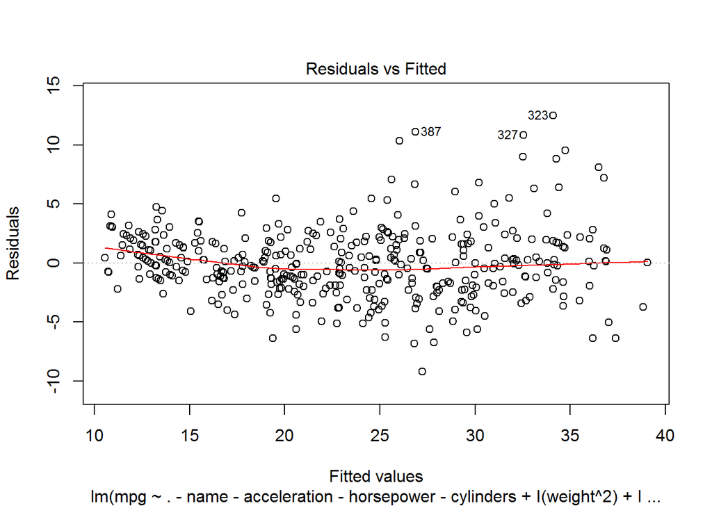

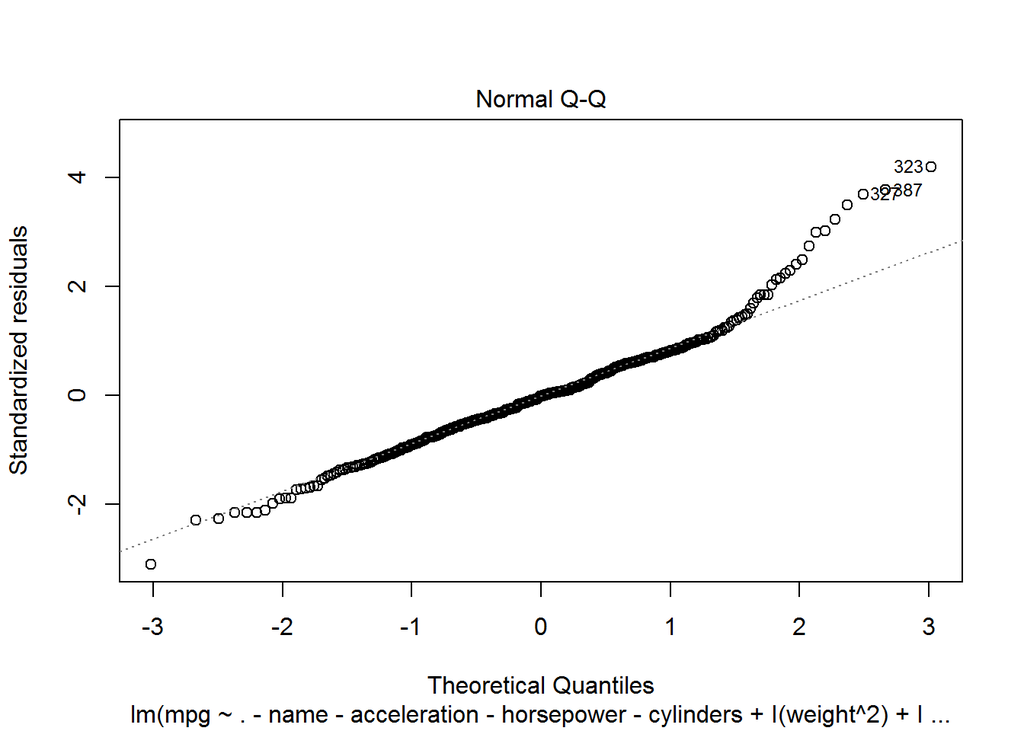

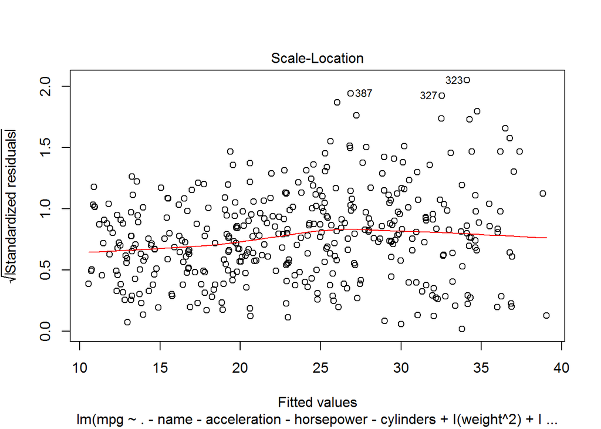

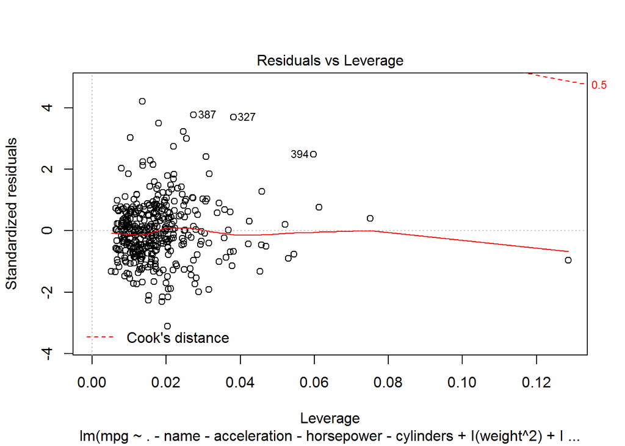

```r
plot(auto.lm4)
```

10. This question should be answered using the Carseats data set.
1. Fit a multiple regression model to predict Sales using Price, Urban, and US.

```r
library(ISLR)
fix(Carseats)

seat.lm <- lm(Sales~Price+Urban+US, data = Carseats)
summary(seat.lm)
```

```
##
## Call:
## lm(formula = Sales ~ Price + Urban + US, data = Carseats)
##
## Residuals:
##     Min      1Q  Median      3Q     Max
## -6.9206 -1.6220 -0.0564  1.5786  7.0581
##
## Coefficients:
##              Estimate Std. Error t value Pr(>|t|)
## (Intercept) 13.043469   0.651012  20.036  < 2e-16 ***
## Price       -0.054459   0.005242 -10.389  < 2e-16 ***
## UrbanYes    -0.021916   0.271650  -0.081    0.936
## USYes        1.200573   0.259042   4.635 4.86e-06 ***
## ---
## Signif. codes:  0 '***' 0.001 '**' 0.01 '*' 0.05 '.' 0.1 ' ' 1
##
## Residual standard error: 2.472 on 396 degrees of freedom
## Multiple R-squared:  0.2393, Adjusted R-squared:  0.2335
## F-statistic: 41.52 on 3 and 396 DF,  p-value: < 2.2e-16
```

2. Provide an interpretation of each coefficient in the model. Be careful—some of the variables in the model are qualitative!

Price has a significant, negative relationship with sales. The value of the Urban variable does not appear to have an impact on the value of the sales variable. The US variable, however, does have an impact on sales. Entries in the dataset with ‘Yes’ in the US column have an average Sales value that is 1.2 higher than entries with ‘No’ in the US column, holding Price and Urban fixed.

3. Write out the model in equation form, being careful to handle the qualitative variables properly.
4. For which of the predictors can you reject the null hypothesis H0 : ßj = 0?

Price and US (USYes)

5. On the basis of your response to the previous question, fit a smaller model that only uses the predictors for which there is evidence of association with the outcome.

```r
seat.lm2 <- lm(Sales~Price+US, data = Carseats)
summary(seat.lm2)
```

```
##
## Call:
## lm(formula = Sales ~ Price + US, data = Carseats)
##
## Residuals:
##     Min      1Q  Median      3Q     Max
## -6.9269 -1.6286 -0.0574  1.5766  7.0515
##
## Coefficients:
##             Estimate Std. Error t value Pr(>|t|)
## (Intercept) 13.03079    0.63098  20.652  < 2e-16 ***
## Price       -0.05448    0.00523 -10.416  < 2e-16 ***
## USYes        1.19964    0.25846   4.641 4.71e-06 ***
## ---
## Signif. codes:  0 '***' 0.001 '**' 0.01 '*' 0.05 '.' 0.1 ' ' 1
##
## Residual standard error: 2.469 on 397 degrees of freedom
## Multiple R-squared:  0.2393, Adjusted R-squared:  0.2354
## F-statistic: 62.43 on 2 and 397 DF,  p-value: < 2.2e-16
```

6. How well do the models in (a) and (e) fit the data?

They both have near-zero p values, so the relationship is statistically significant. However, the adjusted R squared for each is ~0.23 meaning that the model accounts for less than a quarter of the variability of the response.

7. Using the model from (e), obtain 95% confidence intervals for the coefficient(s).

```r
confint(seat.lm2)
```

```
##                   2.5 %      97.5 %
## (Intercept) 11.79032020 14.27126531
## Price       -0.06475984 -0.04419543
## USYes        0.69151957  1.70776632
```

An approximation, hand calculated: Intercept: 11.77 - 14.29 Price: -0.0645 - -.0445 USYes: 0.68 - 1.72

8. Is there evidence of outliers or high leverage observations in the model from (e)?

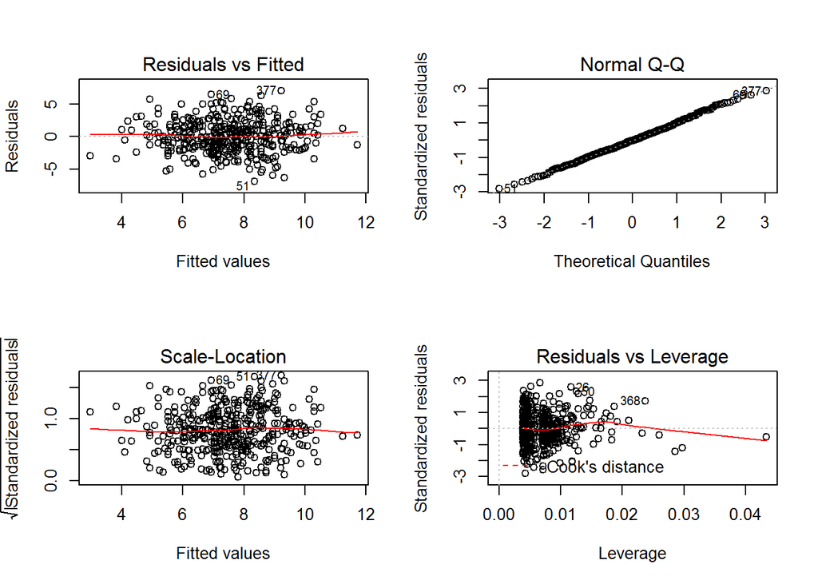

```r
par(mfrow = c(2,2))
plot(seat.lm2)
```

There is one point withn noticeably higher leverage than average but it has a small residual value and doesn’t have a concerningly high leverage score in my estimation.

11. In this problem we will investigate the t-statistic for the null hypothesis H0 : ß = 0 in simple linear regression without an intercept. To begin, we generate a predictor x and a response y as follows.
1. Perform a simple linear regression of y onto x, without an intercept. Report the coefficient estimate ˆß, the standard error of this coefficient estimate, and the t-statistic and p-value associated with the null hypothesis H0 : ß = 0. Comment on these results. (You can perform regression without an intercept using the command lm(y~x+0).)

```r
set.seed(1)
x=rnorm(100)
y=2*x+rnorm(100)

lm.fit <- lm(y~x+0)
summary(lm.fit)
```

```
##
## Call:
## lm(formula = y ~ x + 0)
##
## Residuals:
##     Min      1Q  Median      3Q     Max
## -1.9154 -0.6472 -0.1771  0.5056  2.3109
##
## Coefficients:
##   Estimate Std. Error t value Pr(>|t|)
## x   1.9939     0.1065   18.73   <2e-16 ***
## ---
## Signif. codes:  0 '***' 0.001 '**' 0.01 '*' 0.05 '.' 0.1 ' ' 1
##
## Residual standard error: 0.9586 on 99 degrees of freedom
## Multiple R-squared:  0.7798, Adjusted R-squared:  0.7776
## F-statistic: 350.7 on 1 and 99 DF,  p-value: < 2.2e-16
```

2. Now perform a simple linear regression of x onto y without an intercept, and report the coefficient estimate, its standard error, and the corresponding t-statistic and p-values associated with the null hypothesis H0 : ß = 0. Comment on these results.

```r
lm.fit2 <- lm(x~y+0)
summary(lm.fit2)
```

```
##
## Call:
## lm(formula = x ~ y + 0)
##
## Residuals:
##     Min      1Q  Median      3Q     Max
## -0.8699 -0.2368  0.1030  0.2858  0.8938
##
## Coefficients:
##   Estimate Std. Error t value Pr(>|t|)
## y  0.39111    0.02089   18.73   <2e-16 ***
## ---
## Signif. codes:  0 '***' 0.001 '**' 0.01 '*' 0.05 '.' 0.1 ' ' 1
##
## Residual standard error: 0.4246 on 99 degrees of freedom
## Multiple R-squared:  0.7798, Adjusted R-squared:  0.7776
## F-statistic: 350.7 on 1 and 99 DF,  p-value: < 2.2e-16
```

3. What is the relationship between the results obtained in (a) and (b)?

The t and p values are identical, as are the R squared and adjusted R squared values. The coefficient and standard error have the same ratios between the two models.

```r
1.9939/.3911
```

```
## [1] 5.098185
```

```r
.1065/.02089
```

```
## [1] 5.098133
```

6. In R, show that when regression is performed with an intercept, the t-statistic for H0 : ß1 = 0 is the same for the regression of y onto x as it is for the regression of x onto y.

```r
lm.fit3 <- lm(y~x)
summary(lm.fit3)
```

```
##
## Call:
## lm(formula = y ~ x)
##
## Residuals:
##     Min      1Q  Median      3Q     Max
## -1.8768 -0.6138 -0.1395  0.5394  2.3462
##
## Coefficients:
##             Estimate Std. Error t value Pr(>|t|)
## (Intercept) -0.03769    0.09699  -0.389    0.698
## x            1.99894    0.10773  18.556   <2e-16 ***
## ---
## Signif. codes:  0 '***' 0.001 '**' 0.01 '*' 0.05 '.' 0.1 ' ' 1
##
## Residual standard error: 0.9628 on 98 degrees of freedom
## Multiple R-squared:  0.7784, Adjusted R-squared:  0.7762
## F-statistic: 344.3 on 1 and 98 DF,  p-value: < 2.2e-16
```

```r
lm.fit4 <- lm(x~y)
summary(lm.fit4)
```

```
##
## Call:
## lm(formula = x ~ y)
##
## Residuals:
##      Min       1Q   Median       3Q      Max
## -0.90848 -0.28101  0.06274  0.24570  0.85736
##
## Coefficients:
##             Estimate Std. Error t value Pr(>|t|)
## (Intercept)  0.03880    0.04266    0.91    0.365
## y            0.38942    0.02099   18.56   <2e-16 ***
## ---
## Signif. codes:  0 '***' 0.001 '**' 0.01 '*' 0.05 '.' 0.1 ' ' 1
##
## Residual standard error: 0.4249 on 98 degrees of freedom
## Multiple R-squared:  0.7784, Adjusted R-squared:  0.7762
## F-statistic: 344.3 on 1 and 98 DF,  p-value: < 2.2e-16
```

12. This problem involves simple linear regression without an intercept.
1. Recall that the coefficient estimate ˆ ß for the linear regression of Y onto X without an intercept is given by (3.38). Under what circumstance is the coefficient estimate for the regression of X onto Y the same as the coefficient estimate for the regression of Y onto X?

The coefficients will be the same only when the sum of squares for x and y are equal.

2. Generate an example in R with n = 100 observations in which the coefficient estimate for the regression of X onto Y is different from the coefficient estimate for the regression of Y onto X.

See problem 11 - those coefficient estimates were different.

3. Generate an example in R with n = 100 observations in which the coefficient estimate for the regression of X onto Y is the same as the coefficient estimate for the regression of Y onto X.

```r
y2 <- sample(x,100)
y2 <- -y2

lm.12.fit <- lm(y2~x)
lm.12.fit2 <- lm(x~y2)
summary(lm.12.fit)
```

```
##
## Call:
## lm(formula = y2 ~ x)
##
## Residuals:
##      Min       1Q   Median       3Q      Max
## -2.49405 -0.54430  0.01559  0.54734  2.25999
##
## Coefficients:
##             Estimate Std. Error t value Pr(>|t|)
## (Intercept) -0.13046    0.08914  -1.464   0.1465
## x            0.19814    0.09901   2.001   0.0481 *
## ---
## Signif. codes:  0 '***' 0.001 '**' 0.01 '*' 0.05 '.' 0.1 ' ' 1
##
## Residual standard error: 0.8849 on 98 degrees of freedom
## Multiple R-squared:  0.03926,    Adjusted R-squared:  0.02945
## F-statistic: 4.005 on 1 and 98 DF,  p-value: 0.04814
```

```r
summary(lm.12.fit2)
```

```
##
## Call:
## lm(formula = x ~ y2)
##
## Residuals:
##      Min       1Q   Median       3Q      Max
## -2.04257 -0.52035  0.04825  0.50536  2.27137
##
## Coefficients:
##             Estimate Std. Error t value Pr(>|t|)
## (Intercept)  0.13046    0.08914   1.464   0.1465
## y2           0.19814    0.09901   2.001   0.0481 *
## ---
## Signif. codes:  0 '***' 0.001 '**' 0.01 '*' 0.05 '.' 0.1 ' ' 1
##
## Residual standard error: 0.8849 on 98 degrees of freedom
## Multiple R-squared:  0.03926,    Adjusted R-squared:  0.02945
## F-statistic: 4.005 on 1 and 98 DF,  p-value: 0.04814
```

13. In this exercise you will create some simulated data and will fit simple linear regression models to it. Make sure to use set.seed(1) prior to starting part (a) to ensure consistent results.
1. Using the rnorm() function, create a vector, x, containing 100 observations drawn from a N(0, 1) distribution. This represents a feature, X.
2. Using the rnorm() function, create a vector, eps, containing 100 observations drawn from a N(0, 0.25) distribution i.e. a normal distribution with mean zero and variance 0.25.
3. Using x and eps, generate a vector y according to the model

Y = -1 + 0.5X + eps

What is the length of the vector y? What are the values of ß0 and ß1 in this linear model?

length(y) = 100 Intercept term = -1 Coefficient (x) = 0.5

```r
x <- rnorm(100)
eps <- rnorm(100, mean = 0, sd = .25)
y <- -1 + .5*x + eps
```

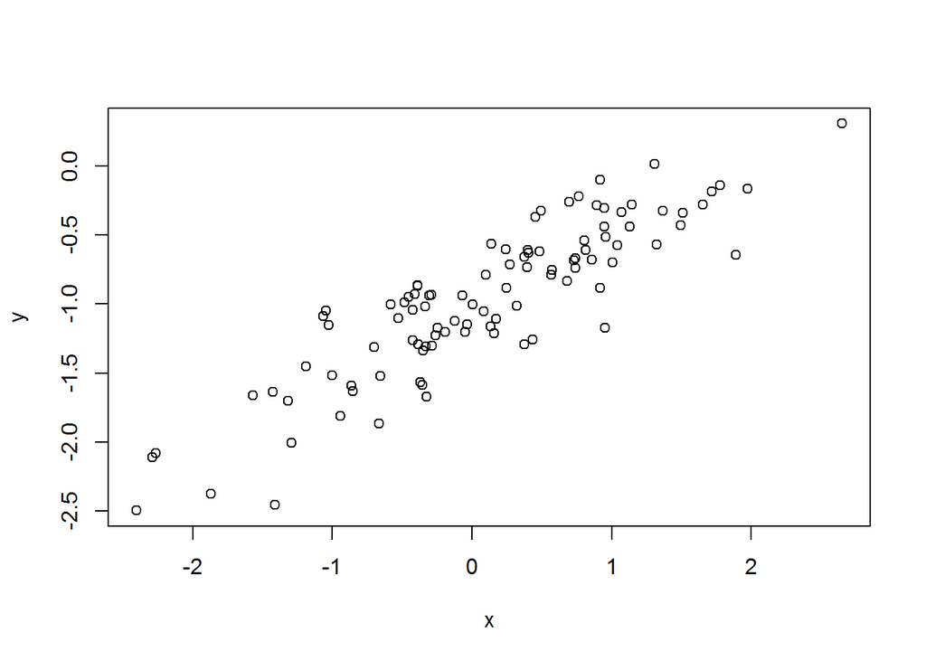

```r
par(mfrow = c(1,1))
plot(x,y)
```

There is a clear pattern to the data but also a fair amount of noise.

5. Fit a least squares linear model to predict y using x. Comment on the model obtained. How do ˆ ß0 and ˆ ß1 compare to ß0 and ß1?

```r
lm.13.fit <- lm(y~x)
summary(lm.13.fit)
```

```
##
## Call:
## lm(formula = y ~ x)
##
## Residuals:
##      Min       1Q   Median       3Q      Max
## -0.72797 -0.14798 -0.01618  0.17955  0.49602
##
## Coefficients:
##             Estimate Std. Error t value Pr(>|t|)
## (Intercept) -1.01649    0.02649  -38.37   <2e-16 ***
## x            0.50536    0.02716   18.61   <2e-16 ***
## ---
## Signif. codes:  0 '***' 0.001 '**' 0.01 '*' 0.05 '.' 0.1 ' ' 1
##
## Residual standard error: 0.2635 on 98 degrees of freedom
## Multiple R-squared:  0.7794, Adjusted R-squared:  0.7771
## F-statistic: 346.2 on 1 and 98 DF,  p-value: < 2.2e-16
```

The predicted coefficients are very close to the actual coefficients. The true coefficients are easily within one standard error of the estimates values.

6. Display the least squares line on the scatterplot obtained in (d). Draw the population regression line on the plot, in a different color. Use the legend() command to create an appropriate legend.

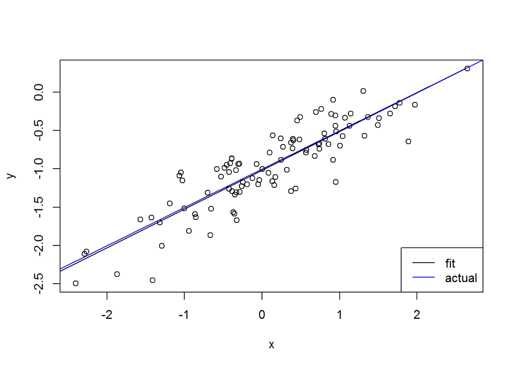

```r
par(mfrow = c(1,1))
plot(x,y)
abline(lm.13.fit)
abline(-1,.5, col = "blue")

legend(x="bottomright", legend = c("fit", "actual"), col = c("black", "blue"), text.col = "black", lty = c(1,1))
```

7. Now fit a polynomial regression model that predicts y using x and x2. Is there evidence that the quadratic term improves the model fit? Explain your answer.

```r
lm.13.fit2 <- lm(y~x+I(x^2))
summary(lm.13.fit2)
```

```
##
## Call:
## lm(formula = y ~ x + I(x^2))
##
## Residuals:
##      Min       1Q   Median       3Q      Max
## -0.69591 -0.15451 -0.00314  0.17979  0.50092
##
## Coefficients:
##             Estimate Std. Error t value Pr(>|t|)
## (Intercept) -0.98760    0.03226 -30.614   <2e-16 ***
## x            0.50578    0.02697  18.753   <2e-16 ***
## I(x^2)      -0.03041    0.01966  -1.547    0.125
## ---
## Signif. codes:  0 '***' 0.001 '**' 0.01 '*' 0.05 '.' 0.1 ' ' 1
##
## Residual standard error: 0.2617 on 97 degrees of freedom
## Multiple R-squared:  0.7847, Adjusted R-squared:  0.7802
## F-statistic: 176.8 on 2 and 97 DF,  p-value: < 2.2e-16
```

```r
summary(lm.13.fit)
```

```
##
## Call:
## lm(formula = y ~ x)
##
## Residuals:
##      Min       1Q   Median       3Q      Max
## -0.72797 -0.14798 -0.01618  0.17955  0.49602
##
## Coefficients:
##             Estimate Std. Error t value Pr(>|t|)
## (Intercept) -1.01649    0.02649  -38.37   <2e-16 ***
## x            0.50536    0.02716   18.61   <2e-16 ***
## ---
## Signif. codes:  0 '***' 0.001 '**' 0.01 '*' 0.05 '.' 0.1 ' ' 1
##
## Residual standard error: 0.2635 on 98 degrees of freedom
## Multiple R-squared:  0.7794, Adjusted R-squared:  0.7771
## F-statistic: 346.2 on 1 and 98 DF,  p-value: < 2.2e-16
```

8. Repeat (a)–(f) after modifying the data generation process in such a way that there is less noise in the data. The model (3.39) should remain the same. You can do this by decreasing the variance of the normal distribution used to generate the error term  in (b). Describe your results.

```r
epsLow <- rnorm(100, mean = 0, sd = 0.05)
yLow <- -1 + 0.5*x + epsLow
lm.13.fit3 <- lm(yLow~x)
summary(lm.13.fit3)
```

```
##
## Call:
## lm(formula = yLow ~ x)
##
## Residuals:
##       Min        1Q    Median        3Q       Max
## -0.116534 -0.039167 -0.004988  0.027930  0.207757
##
## Coefficients:
##              Estimate Std. Error t value Pr(>|t|)
## (Intercept) -0.999448   0.005439 -183.74   <2e-16 ***
## x            0.489994   0.005577   87.86   <2e-16 ***
## ---
## Signif. codes:  0 '***' 0.001 '**' 0.01 '*' 0.05 '.' 0.1 ' ' 1
##
## Residual standard error: 0.05411 on 98 degrees of freedom
## Multiple R-squared:  0.9875, Adjusted R-squared:  0.9873
## F-statistic:  7720 on 1 and 98 DF,  p-value: < 2.2e-16
```

1. Repeat (a)–(f) after modifying the data generation process in such a way that there is more noise in the data. The model (3.39) should remain the same. You can do this by increasing the variance of the normal distribution used to generate the error term  in (b). Describe your results.

```r
epsHigh <- rnorm(100, mean = 0, sd = 2)
yHigh <- -1 + 0.5*x + epsHigh
lm.13.fit4 <- lm(yHigh ~ x)
summary(lm.13.fit4)
```

```
##
## Call:
## lm(formula = yHigh ~ x)
##
## Residuals:
##     Min      1Q  Median      3Q     Max
## -4.6658 -1.2804 -0.2809  1.5746  5.5235
##
## Coefficients:
##             Estimate Std. Error t value Pr(>|t|)
## (Intercept)  -1.1733     0.2107  -5.567 2.26e-07 ***
## x             0.4646     0.2161   2.150    0.034 *
## ---
## Signif. codes:  0 '***' 0.001 '**' 0.01 '*' 0.05 '.' 0.1 ' ' 1
##
## Residual standard error: 2.096 on 98 degrees of freedom
## Multiple R-squared:  0.04506,    Adjusted R-squared:  0.03531
## F-statistic: 4.624 on 1 and 98 DF,  p-value: 0.03399
```

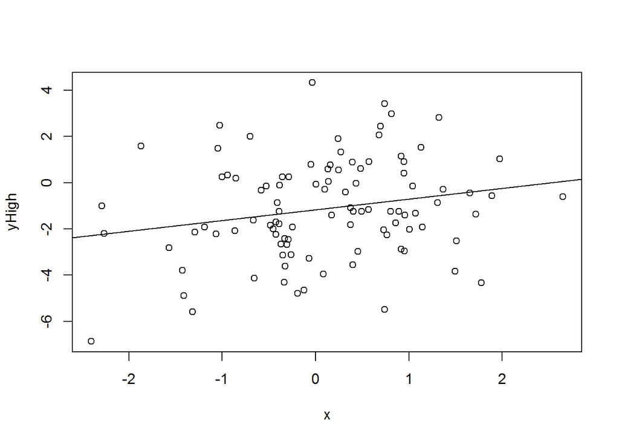

```r
plot(x, yHigh)
abline(lm.13.fit4)
```

10. What are the confidence intervals for ß0 and ß1 based on the original data set, the noisier data set, and the less noisy data set? Comment on your results.

```r
# Starter model, moderate noise
confint(lm.13.fit)
```

```
##                 2.5 %     97.5 %
## (Intercept) -1.069061 -0.9639147
## x            0.451461  0.5592611
```

```r
# Second model, less noise
confint(lm.13.fit3)
```

```
##                  2.5 %     97.5 %
## (Intercept) -1.0102427 -0.9886540
## x            0.4789273  0.5010609
```

```r
# Third Model, more noise
confint(lm.13.fit4)
```

```
##                   2.5 %     97.5 %
## (Intercept) -1.59155033 -0.7550997
## x            0.03584074  0.8934015
```

The confidence intervals widen as more noise is added.

14. This problem focuses on the collinearity problem.

```r
set.seed(1)
x1 <- runif(100)
x2 <- 0.5*x1+rnorm(100)/10
y=2+2*x1+0.3*x2+rnorm(100)
```

2. What is the correlation between x1 and x2? Create a scatterplot displaying the relationship between the variables.

```r
cor(x1,x2)
```

```
## [1] 0.8351212
```

3. Using this data, fit a least squares regression to predict y using x1 and x2. Describe the results obtained. What are ˆ ß0, ˆ ß1, and ˆ ß2? How do these relate to the true ß0, ß1, and ß2? Can you reject the null hypothesis H0 : ß1 = 0? How about the null hypothesis H0 : ß2 = 0?

```r
lm.14.fit <- lm(y~x1+x2)
summary(lm.14.fit)
```

```
##
## Call:
## lm(formula = y ~ x1 + x2)
##
## Residuals:
##     Min      1Q  Median      3Q     Max
## -2.8311 -0.7273 -0.0537  0.6338  2.3359
##
## Coefficients:
##             Estimate Std. Error t value Pr(>|t|)
## (Intercept)   2.1305     0.2319   9.188 7.61e-15 ***
## x1            1.4396     0.7212   1.996   0.0487 *
## x2            1.0097     1.1337   0.891   0.3754
## ---
## Signif. codes:  0 '***' 0.001 '**' 0.01 '*' 0.05 '.' 0.1 ' ' 1
##
## Residual standard error: 1.056 on 97 degrees of freedom
## Multiple R-squared:  0.2088, Adjusted R-squared:  0.1925
## F-statistic:  12.8 on 2 and 97 DF,  p-value: 1.164e-05
```

All of the coefficient estimates are within one standard error of the true value, but the standard errors are quite large for the x1 and x2 coefficients. The overall p value of the model is very low, indicating that the model is significant. However, with a R squared of ~ 0.2, the model doesn’t go a long way in explaining the variability of the response. The null hypothesis can be rejected for the intercept and the X1 term but not for the x2 term.

4. Now fit a least squares regression to predict y using only x1. Comment on your results. Can you reject the null hypothesis H0 : ß1 = 0?

```r
lm.14.fit2 <- lm(y~x1)
summary(lm.14.fit2)
```

```
##
## Call:
## lm(formula = y ~ x1)
##
## Residuals:
##      Min       1Q   Median       3Q      Max
## -2.89495 -0.66874 -0.07785  0.59221  2.45560
##
## Coefficients:
##             Estimate Std. Error t value Pr(>|t|)
## (Intercept)   2.1124     0.2307   9.155 8.27e-15 ***
## x1            1.9759     0.3963   4.986 2.66e-06 ***
## ---
## Signif. codes:  0 '***' 0.001 '**' 0.01 '*' 0.05 '.' 0.1 ' ' 1
##
## Residual standard error: 1.055 on 98 degrees of freedom
## Multiple R-squared:  0.2024, Adjusted R-squared:  0.1942
## F-statistic: 24.86 on 1 and 98 DF,  p-value: 2.661e-06
```

The null hypothesis can be rejected. The model maintains approximately the same R squared value as the last model, but the x1 coefficient estimate is much more accurate with a much smaller standard error.

5. Now fit a least squares regression to predict y using only x2. Comment on your results. Can you reject the null hypothesis H0 : ß1 = 0?

```r
lm.14.fit3 <- lm(y~x2)
summary(lm.14.fit3)
```

```
##
## Call:
## lm(formula = y ~ x2)
##
## Residuals:
##      Min       1Q   Median       3Q      Max
## -2.62687 -0.75156 -0.03598  0.72383  2.44890
##
## Coefficients:
##             Estimate Std. Error t value Pr(>|t|)
## (Intercept)   2.3899     0.1949   12.26  < 2e-16 ***
## x2            2.8996     0.6330    4.58 1.37e-05 ***
## ---
## Signif. codes:  0 '***' 0.001 '**' 0.01 '*' 0.05 '.' 0.1 ' ' 1
##
## Residual standard error: 1.072 on 98 degrees of freedom
## Multiple R-squared:  0.1763, Adjusted R-squared:  0.1679
## F-statistic: 20.98 on 1 and 98 DF,  p-value: 1.366e-05
```

Yes, the null hypothesis can be rejected. This model seems to be only slightly inferior, based on R squared and p values, to the previous model. The estimate for the x2 coefficient is very different from the actual value.

6. Do the results obtained in (c)–(e) contradict each other? Explain your answer.

No, because the two terms are highly correlated, it’s not surprising that x2 doesn’t contribute much to the model in the presence of x1 but does when on its own.

7. Now suppose we obtain one additional observation, which was unfortunately mismeasured.

```r
x1=c(x1 , 0.1)
x2=c(x2 , 0.8)
y=c(y,6)
```

Re-fit the linear models from (c) to (e) using this new data. What effect does this new observation have on the each of the models? In each model, is this observation an outlier? A high-leverage point? Both? Explain your answers.

```r
lm.14.fit <- lm(y~x1+x2)
summary(lm.14.fit)
```

```
##
## Call:
## lm(formula = y ~ x1 + x2)
##
## Residuals:
##      Min       1Q   Median       3Q      Max
## -2.73348 -0.69318 -0.05263  0.66385  2.30619
##
## Coefficients:
##             Estimate Std. Error t value Pr(>|t|)
## (Intercept)   2.2267     0.2314   9.624 7.91e-16 ***
## x1            0.5394     0.5922   0.911  0.36458
## x2            2.5146     0.8977   2.801  0.00614 **
## ---
## Signif. codes:  0 '***' 0.001 '**' 0.01 '*' 0.05 '.' 0.1 ' ' 1
##
## Residual standard error: 1.075 on 98 degrees of freedom
## Multiple R-squared:  0.2188, Adjusted R-squared:  0.2029
## F-statistic: 13.72 on 2 and 98 DF,  p-value: 5.564e-06
```

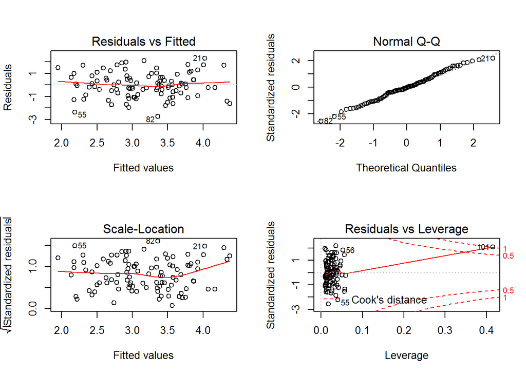

```r
par(mfrow=c(2,2))
plot(lm.14.fit)
```

```r
lm.14.fit2 <- lm(y~x1)
summary(lm.14.fit2)
```

```
##
## Call:
## lm(formula = y ~ x1)
##
## Residuals:
##     Min      1Q  Median      3Q     Max
## -2.8897 -0.6556 -0.0909  0.5682  3.5665
##
## Coefficients:
##             Estimate Std. Error t value Pr(>|t|)
## (Intercept)   2.2569     0.2390   9.445 1.78e-15 ***
## x1            1.7657     0.4124   4.282 4.29e-05 ***
## ---
## Signif. codes:  0 '***' 0.001 '**' 0.01 '*' 0.05 '.' 0.1 ' ' 1
##
## Residual standard error: 1.111 on 99 degrees of freedom
## Multiple R-squared:  0.1562, Adjusted R-squared:  0.1477
## F-statistic: 18.33 on 1 and 99 DF,  p-value: 4.295e-05
```

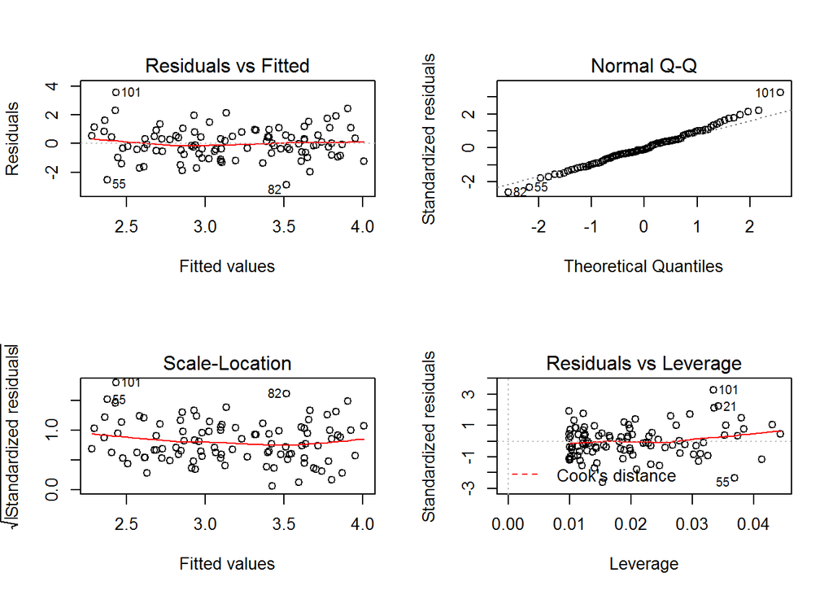

```r
plot(lm.14.fit2)
```

```r
lm.14.fit3 <- lm(y~x2)
summary(lm.14.fit3)
```

```
##
## Call:
## lm(formula = y ~ x2)
##
## Residuals:
##      Min       1Q   Median       3Q      Max
## -2.64729 -0.71021 -0.06899  0.72699  2.38074
##
## Coefficients:
##             Estimate Std. Error t value Pr(>|t|)
## (Intercept)   2.3451     0.1912  12.264  < 2e-16 ***
## x2            3.1190     0.6040   5.164 1.25e-06 ***
## ---
## Signif. codes:  0 '***' 0.001 '**' 0.01 '*' 0.05 '.' 0.1 ' ' 1
##
## Residual standard error: 1.074 on 99 degrees of freedom
## Multiple R-squared:  0.2122, Adjusted R-squared:  0.2042
## F-statistic: 26.66 on 1 and 99 DF,  p-value: 1.253e-06
```

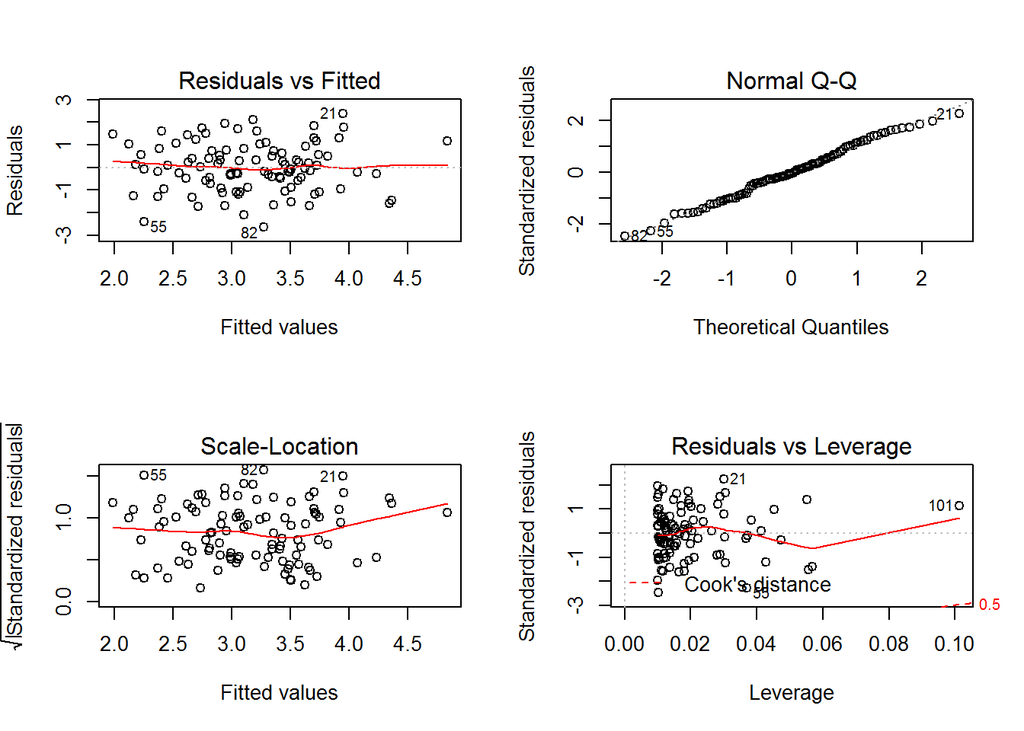

```r
plot(lm.14.fit3)
```

15. This problem involves the Boston data set, which we saw in the lab for this chapter. We will now try to predict per capita crime rate using the other variables in this data set. In other words, per capita crime rate is the response, and the other variables are the predictors.
1. For each predictor, fit a simple linear regression model to predict the response. Describe your results. In which of the models is there a statistically significant association between the predictor and the response? Create some plots to back up your assertions.

All of the models except for chas have significant p values. indus, nox, age, rad, and tax all have an R squared value over 0.15.

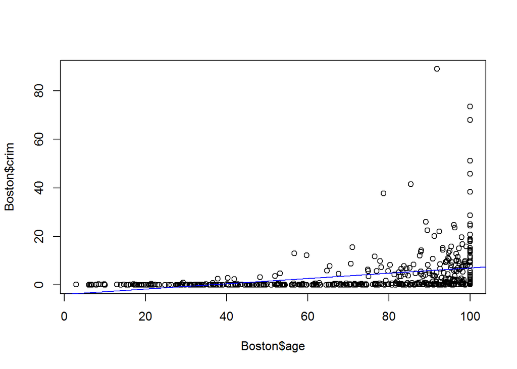

```r
library(MASS)
fix(Boston)

par(mfrow=c(1,1))

lm.15.age <- lm(crim~age, data = Boston)
plot(Boston$age, Boston$crim)
abline(lm.15.age, col = "blue")
```

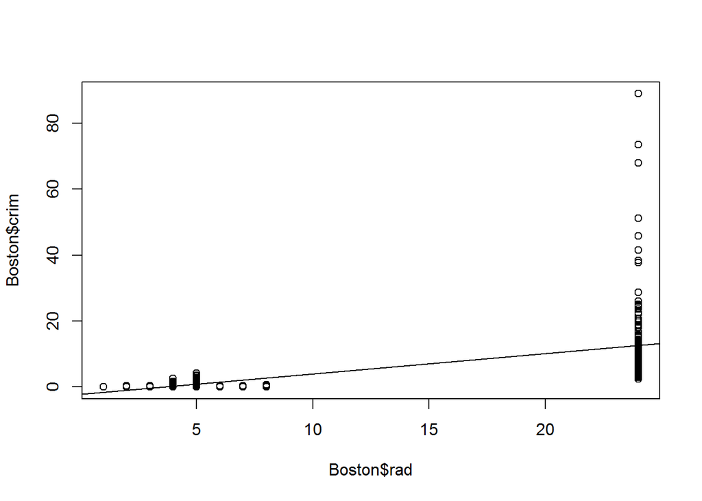

```r
lm.15.rad <- lm(crim~rad, data = Boston)
plot(Boston$rad, Boston$crim)
abline(lm.15.rad)
```

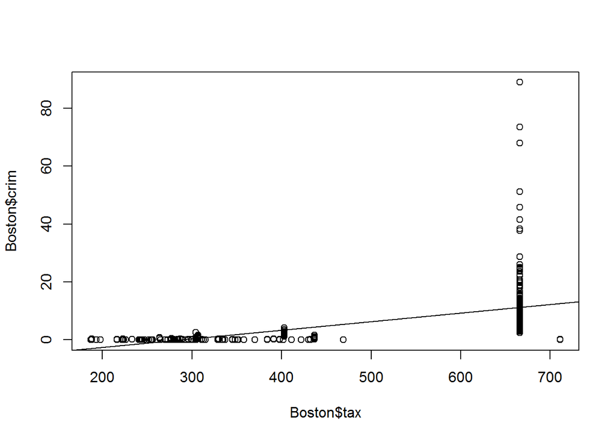

```r
lm.15.tax <- lm(crim~tax, data = Boston)
plot(Boston$tax, Boston$crim)
abline(lm.15.tax)
```

2. Fit a multiple regression model to predict the response using all of the predictors. Describe your results. For which predictors can we reject the null hypothesis H0 : ßj = 0?

```r
lm.15.fit2 <- lm(crim~., data=Boston)
summary(lm.15.fit2)
```

```
##
## Call:
## lm(formula = crim ~ ., data = Boston)
##
## Residuals:
##    Min     1Q Median     3Q    Max
## -9.924 -2.120 -0.353  1.019 75.051
##
## Coefficients:
##               Estimate Std. Error t value Pr(>|t|)
## (Intercept)  17.033228   7.234903   2.354 0.018949 *
## zn            0.044855   0.018734   2.394 0.017025 *
## indus        -0.063855   0.083407  -0.766 0.444294
## chas         -0.749134   1.180147  -0.635 0.525867
## nox         -10.313535   5.275536  -1.955 0.051152 .
## rm            0.430131   0.612830   0.702 0.483089
## age           0.001452   0.017925   0.081 0.935488
## dis          -0.987176   0.281817  -3.503 0.000502 ***
## rad           0.588209   0.088049   6.680 6.46e-11 ***
## tax          -0.003780   0.005156  -0.733 0.463793
## ptratio      -0.271081   0.186450  -1.454 0.146611
## black        -0.007538   0.003673  -2.052 0.040702 *
## lstat         0.126211   0.075725   1.667 0.096208 .
## medv         -0.198887   0.060516  -3.287 0.001087 **
## ---
## Signif. codes:  0 '***' 0.001 '**' 0.01 '*' 0.05 '.' 0.1 ' ' 1
##
## Residual standard error: 6.439 on 492 degrees of freedom
## Multiple R-squared:  0.454,  Adjusted R-squared:  0.4396
## F-statistic: 31.47 on 13 and 492 DF,  p-value: < 2.2e-16
```

We can reject the null hypothesis for medv, black, dis, rad, and zn.

3. How do your results from (a) compare to your results from (b)? Create a plot displaying the univariate regression coefficients from (a) on the x-axis, and the multiple regression coefficients from (b) on the y-axis. That is, each predictor is displayed as a single point in the plot. Its coefficient in a simple linear regression model is shown on the x-axis, and its coefficient estimate in the multiple linear regression model is shown on the y-axis.

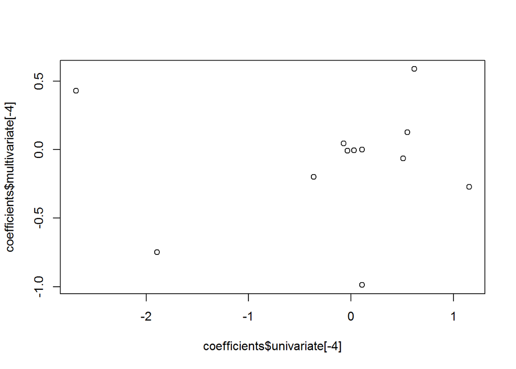

```r
univariate <- c(lm.15.zn$coefficients[2], lm.15.indus$coefficients[2], lm.15.chas$coefficients[2],
                lm.15.nox$coefficients[2], lm.15.rm$coefficients[2], lm.15.age$coefficients[2],
                lm.15.dis$coefficients[2], lm.15.rad$coefficients[2], lm.15.tax$coefficients[2],
                lm.15.ptratio$coefficients[2], lm.15.black$coefficients[2],
                lm.15.lstat$coefficients[2],lm.15.medv$coefficients[2])

coefficients <- data.frame('multivariate' = lm.15.fit2$coefficients[2:14],
                           'univariate' = univariate)

# Excluding the row for nox as it changes from -10 in the multivariate
# to 30 in the univariate. This modifies the scale of the plot and
# makes it difficult to spot the smaller differences in other predictors.
plot(coefficients$univariate[-4], coefficients$multivariate[-4])
```

Many of the variables have significant polynomial predictors that improve the adjusted R squared. nox and dis had the most compelling improvements in adjusted R squared with the addition of polynomial terms.

```r
summary(lm.15.nox)
```

```
##
## Call:
## lm(formula = crim ~ poly(nox, 3), data = Boston)
##
## Residuals:
##    Min     1Q Median     3Q    Max
## -9.110 -2.068 -0.255  0.739 78.302
##
## Coefficients:
##               Estimate Std. Error t value Pr(>|t|)
## (Intercept)     3.6135     0.3216  11.237  < 2e-16 ***
## poly(nox, 3)1  81.3720     7.2336  11.249  < 2e-16 ***
## poly(nox, 3)2 -28.8286     7.2336  -3.985 7.74e-05 ***
## poly(nox, 3)3 -60.3619     7.2336  -8.345 6.96e-16 ***
## ---
## Signif. codes:  0 '***' 0.001 '**' 0.01 '*' 0.05 '.' 0.1 ' ' 1
##
## Residual standard error: 7.234 on 502 degrees of freedom
## Multiple R-squared:  0.297,  Adjusted R-squared:  0.2928
## F-statistic: 70.69 on 3 and 502 DF,  p-value: < 2.2e-16
```

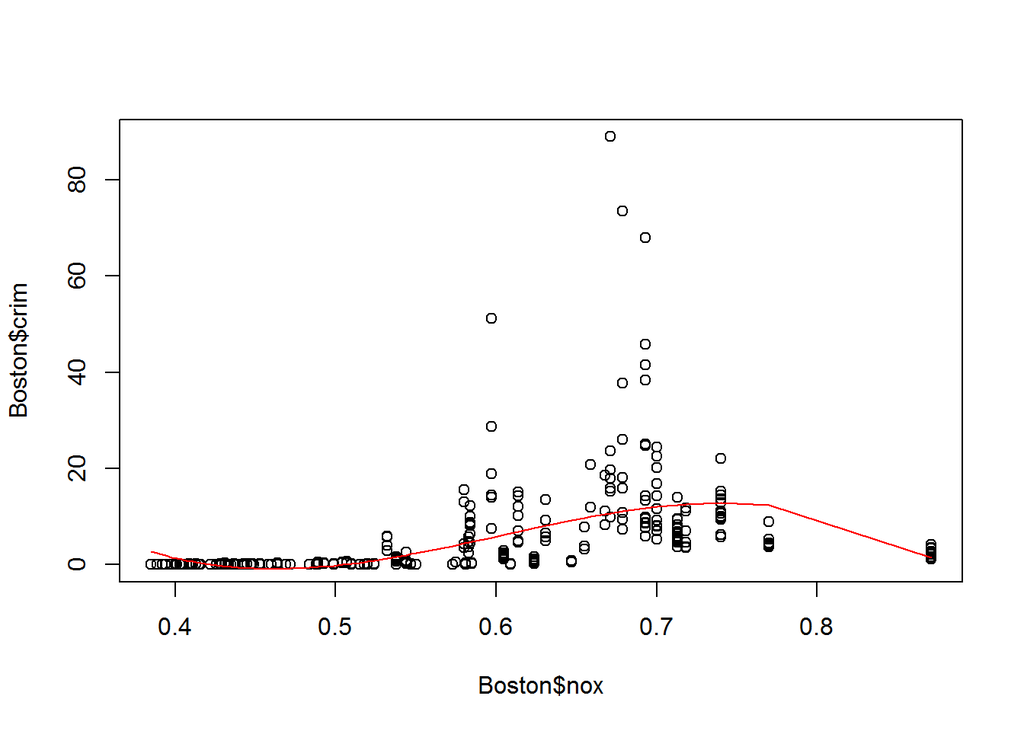

```r
plot(Boston$nox, Boston$crim)
lines(sort(Boston$nox), fitted(lm.15.nox)[order(Boston$nox)], col='red')
```

```r
summary(lm.15.dis)
```

```
##
## Call:
## lm(formula = crim ~ poly(dis, 3), data = Boston)
##
## Residuals:
##     Min      1Q  Median      3Q     Max
## -10.757  -2.588   0.031   1.267  76.378
##
## Coefficients:
##               Estimate Std. Error t value Pr(>|t|)
## (Intercept)     3.6135     0.3259  11.087  < 2e-16 ***
## poly(dis, 3)1 -73.3886     7.3315 -10.010  < 2e-16 ***
## poly(dis, 3)2  56.3730     7.3315   7.689 7.87e-14 ***
## poly(dis, 3)3 -42.6219     7.3315  -5.814 1.09e-08 ***
## ---
## Signif. codes:  0 '***' 0.001 '**' 0.01 '*' 0.05 '.' 0.1 ' ' 1
##
## Residual standard error: 7.331 on 502 degrees of freedom
## Multiple R-squared:  0.2778, Adjusted R-squared:  0.2735
## F-statistic: 64.37 on 3 and 502 DF,  p-value: < 2.2e-16
```

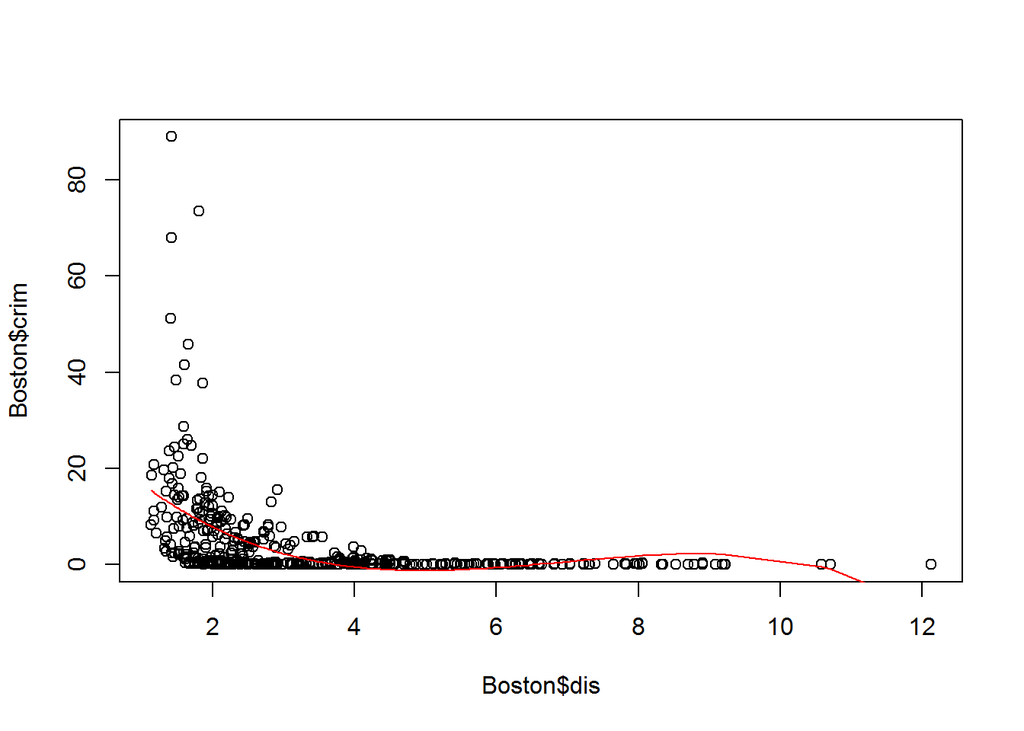

```r
plot(Boston$dis, Boston$crim)
lines(sort(Boston$dis), fitted(lm.15.dis)[order(Boston$dis)], col='red')
```